# Quality Management Plan, Quarterly Report for Quarter 4, 2017 – Red

## Useful Strengths at Entry

These graphs report percentages of clients experiencing particular useful and centerpiece strengths (those rated as a ‘0’ or ‘1’ on the CANS in the Youth Strengths domain) at Initial assessment and, if applicable, the percentage of client scores on these same items at a later reassessment.

### Across All Clients

#### 2015 Cohort

##### Initial

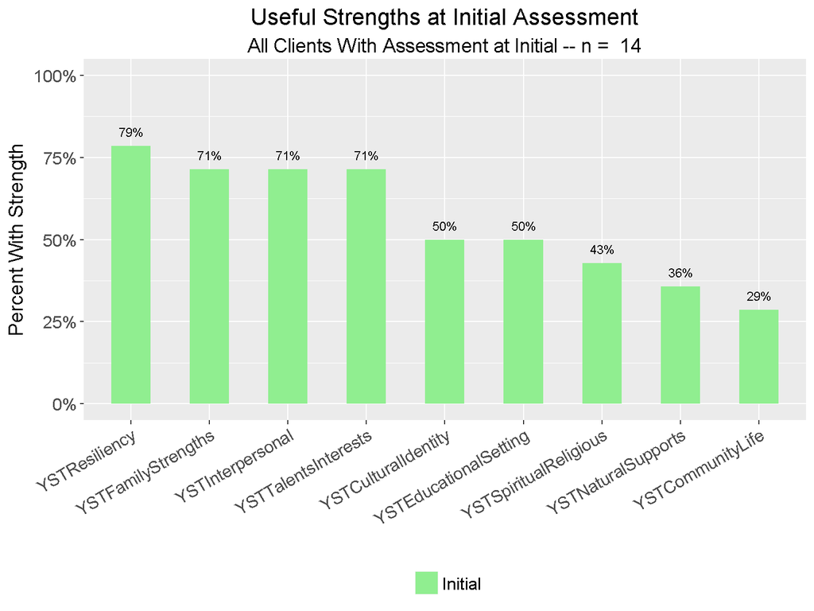

##### 3mo

**A graph cannot be generated, because in the given cohort year and sample, fewer than 10 clients were assessed.**

##### 6mo

**A graph cannot be generated, because in the given cohort year and sample, fewer than 10 clients were assessed.**

##### 9mo

**A graph cannot be generated, because in the given cohort year and sample, fewer than 10 clients were assessed.**

##### 12mo

**A graph cannot be generated, because in the given cohort year and sample, fewer than 10 clients were assessed.**

##### 15mo

**A graph cannot be generated, because in the given cohort year and sample, fewer than 10 clients were assessed.**

##### 18mo

**A graph cannot be generated, because in the given cohort year and sample, fewer than 10 clients were assessed.**

##### 21mo

**A graph cannot be generated, because in the given cohort year and sample, fewer than 10 clients were assessed.**

##### 24mo

**A graph cannot be generated, because in the given cohort year and sample, fewer than 10 clients were assessed.**

##### 27mo

**A graph cannot be generated, because in the given cohort year and sample, fewer than 10 clients were assessed.**

#### 2016 Cohort

##### Initial

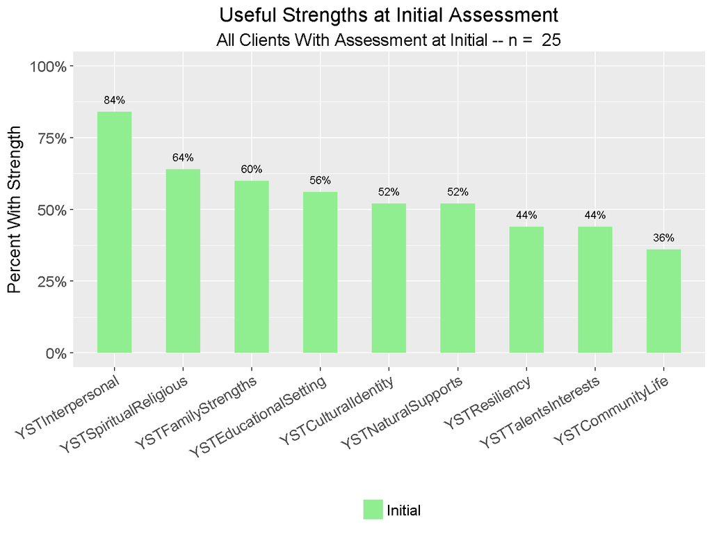

##### 3mo

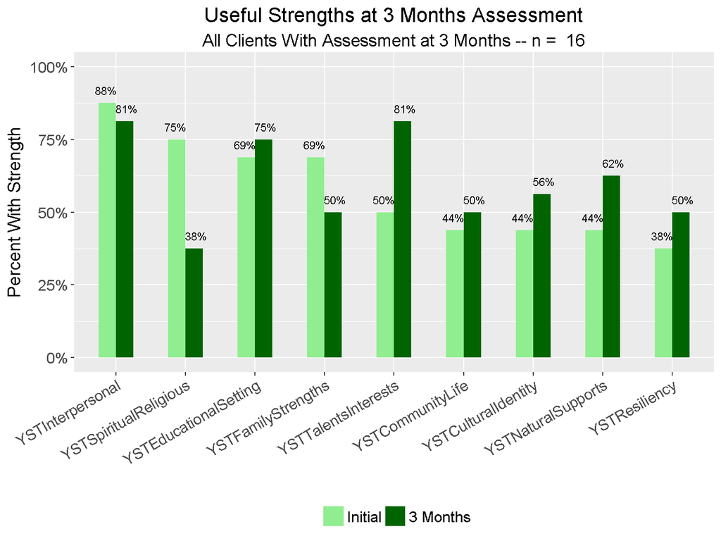

##### 6mo

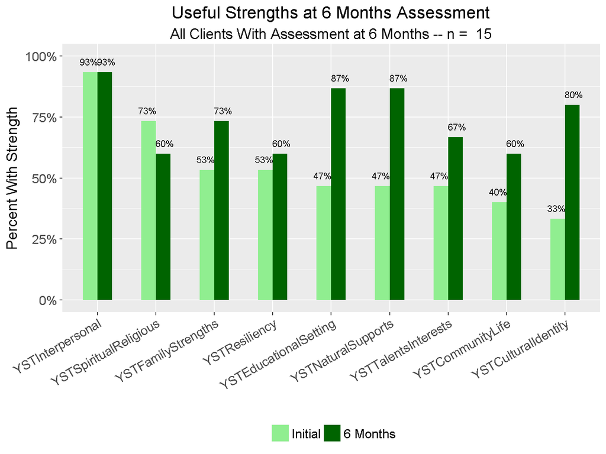

##### 9mo

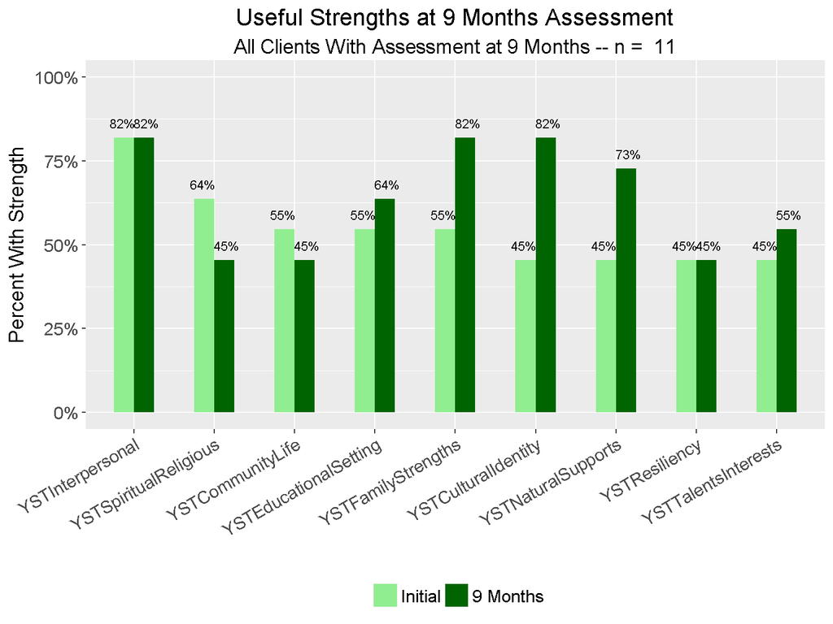

##### 12mo

**A graph cannot be generated, because in the given cohort year and sample, fewer than 10 clients were assessed.**

##### 15mo

**A graph cannot be generated, because in the given cohort year and sample, fewer than 10 clients were assessed.**

##### 18mo

**A graph cannot be generated, because in the given cohort year and sample, fewer than 10 clients were assessed.**

#### 2017 Cohort

##### Initial

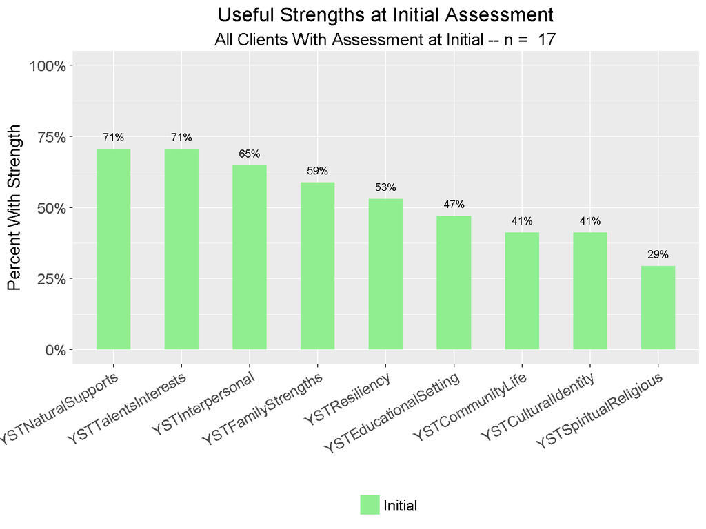

##### 3mo

**A graph cannot be generated, because in the given cohort year and sample, fewer than 10 clients were assessed.**

#### All Cohort

##### Initial

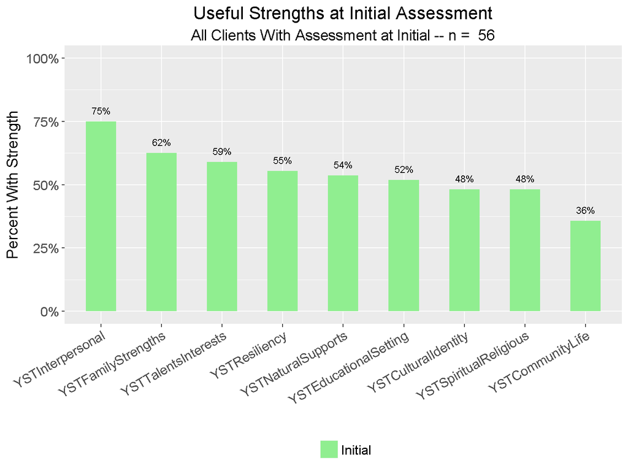

##### 3mo

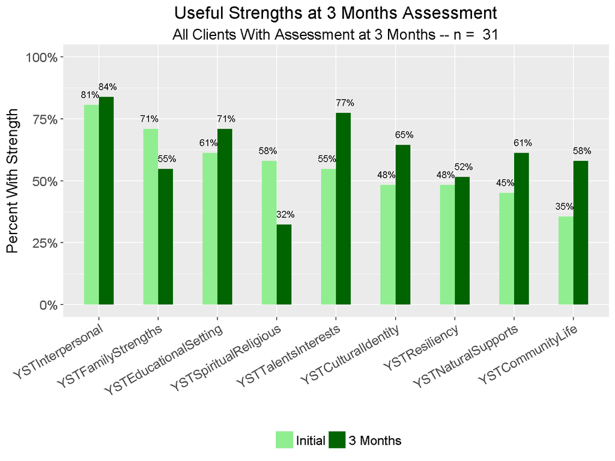

##### 6mo

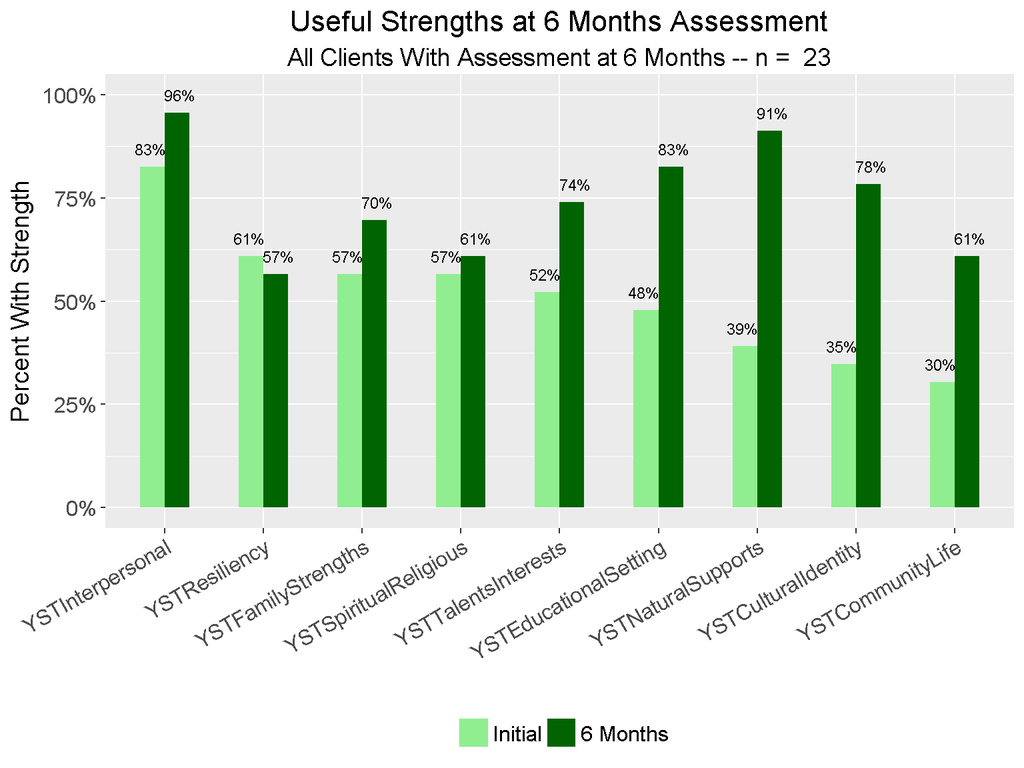

##### 9mo

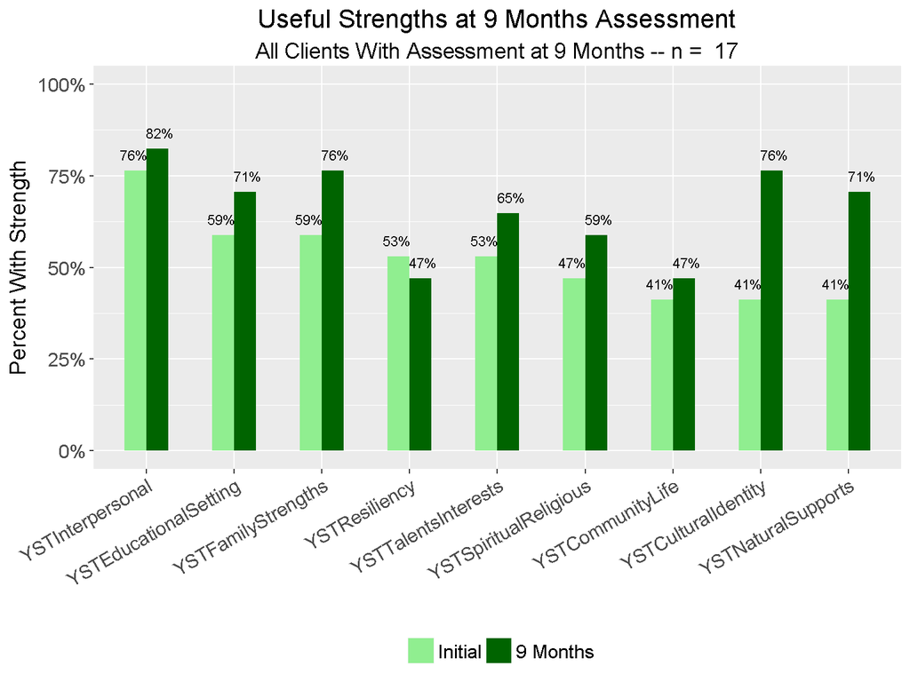

##### 12mo

**A graph cannot be generated, because in the given cohort year and sample, fewer than 10 clients were assessed.**

##### 15mo

**A graph cannot be generated, because in the given cohort year and sample, fewer than 10 clients were assessed.**

##### 18mo

**A graph cannot be generated, because in the given cohort year and sample, fewer than 10 clients were assessed.**

##### 21mo

**A graph cannot be generated, because in the given cohort year and sample, fewer than 10 clients were assessed.**

##### 24mo

**A graph cannot be generated, because in the given cohort year and sample, fewer than 10 clients were assessed.**

##### 27mo

**A graph cannot be generated, because in the given cohort year and sample, fewer than 10 clients were assessed.**

### Discharged After Reassessment

The figures below focus on only clients discharged from care as of the indicated reassessment.

#### 2015 Cohort

##### 3mo

**A graph cannot be generated, because in the given cohort year and sample, fewer than 10 clients were assessed.**

##### 6mo

**A graph cannot be generated, because in the given cohort year and sample, fewer than 10 clients were assessed.**

##### 9mo

**A graph cannot be generated, because in the given cohort year and sample, fewer than 10 clients were assessed.**

##### 18mo

**A graph cannot be generated, because in the given cohort year and sample, fewer than 10 clients were assessed.**

#### 2016 Cohort

##### Initial

**A graph cannot be generated, because in the given cohort year and sample, fewer than 10 clients were assessed.**

##### 3mo

**A graph cannot be generated, because in the given cohort year and sample, fewer than 10 clients were assessed.**

##### 6mo

**A graph cannot be generated, because in the given cohort year and sample, fewer than 10 clients were assessed.**

##### 9mo

**A graph cannot be generated, because in the given cohort year and sample, fewer than 10 clients were assessed.**

##### 12mo

**A graph cannot be generated, because in the given cohort year and sample, fewer than 10 clients were assessed.**

#### 2017 Cohort

##### 3mo

**A graph cannot be generated, because in the given cohort year and sample, fewer than 10 clients were assessed.**

#### All Cohort

##### Initial

**A graph cannot be generated, because in the given cohort year and sample, fewer than 10 clients were assessed.**

##### 3mo

**A graph cannot be generated, because in the given cohort year and sample, fewer than 10 clients were assessed.**

##### 6mo

**A graph cannot be generated, because in the given cohort year and sample, fewer than 10 clients were assessed.**

##### 9mo

**A graph cannot be generated, because in the given cohort year and sample, fewer than 10 clients were assessed.**

##### 12mo

**A graph cannot be generated, because in the given cohort year and sample, fewer than 10 clients were assessed.**

##### 18mo

**A graph cannot be generated, because in the given cohort year and sample, fewer than 10 clients were assessed.**

### Continuing After Reassessment

The figures below focus on only clients continuing in care as of the indicated reassessment.

#### 2015 Cohort

##### Initial

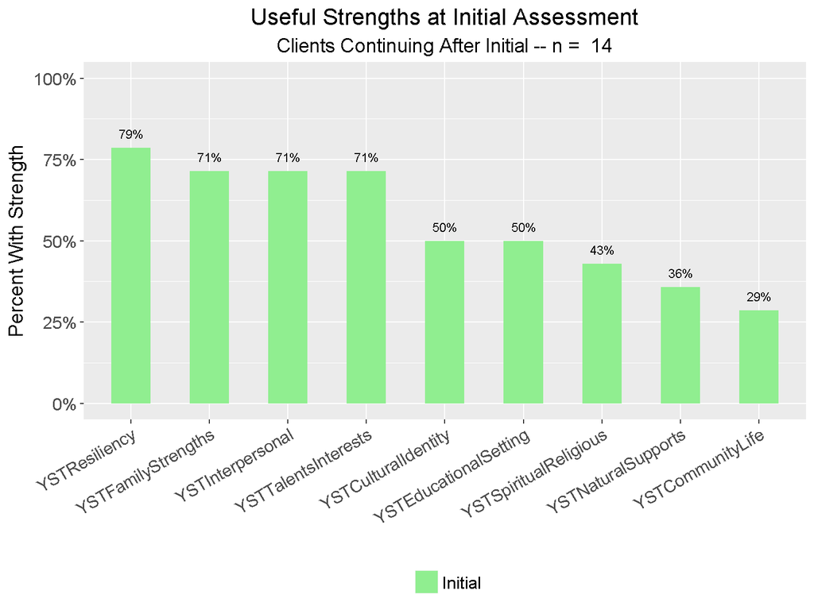

##### 3mo

**A graph cannot be generated, because in the given cohort year and sample, fewer than 10 clients were assessed.**

##### 6mo

**A graph cannot be generated, because in the given cohort year and sample, fewer than 10 clients were assessed.**

##### 9mo

**A graph cannot be generated, because in the given cohort year and sample, fewer than 10 clients were assessed.**

##### 12mo

**A graph cannot be generated, because in the given cohort year and sample, fewer than 10 clients were assessed.**

##### 15mo

**A graph cannot be generated, because in the given cohort year and sample, fewer than 10 clients were assessed.**

##### 18mo

**A graph cannot be generated, because in the given cohort year and sample, fewer than 10 clients were assessed.**

##### 21mo

**A graph cannot be generated, because in the given cohort year and sample, fewer than 10 clients were assessed.**

##### 24mo

**A graph cannot be generated, because in the given cohort year and sample, fewer than 10 clients were assessed.**

##### 27mo

**A graph cannot be generated, because in the given cohort year and sample, fewer than 10 clients were assessed.**

#### 2016 Cohort

##### Initial

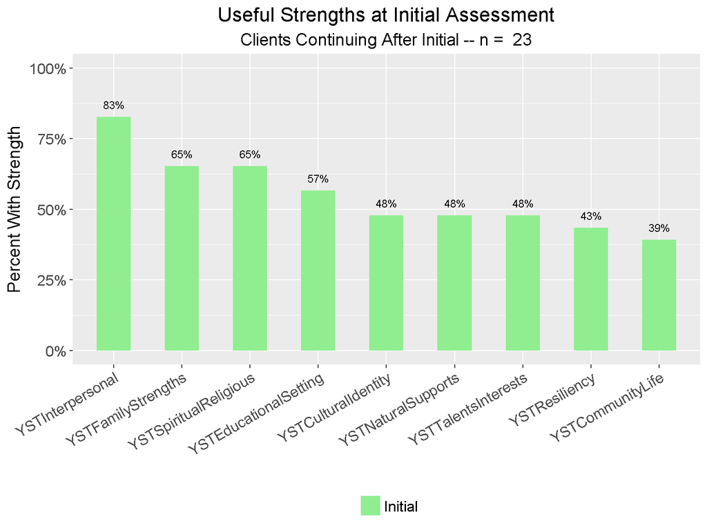

##### 3mo

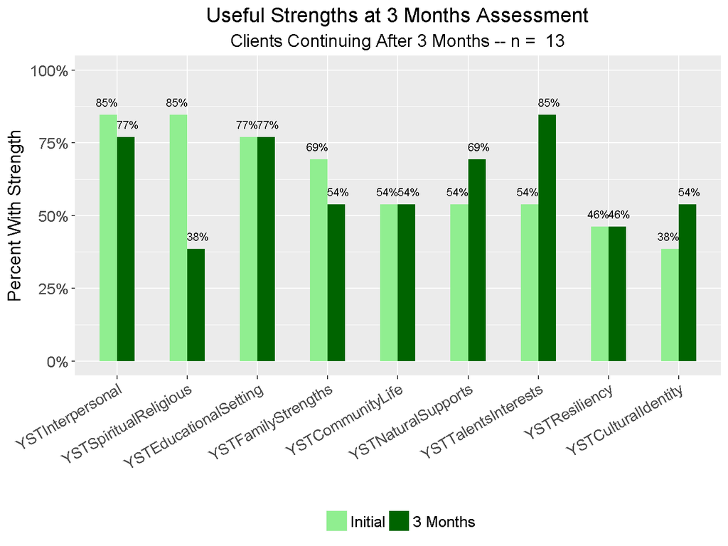